# titanic_Random_Forest

Titanic Dataset - Take 5

# Introduction

Hello all!

This notebook was built after a lot of study and help from the kaggle community and courses. Feel free to copy the code to study and develop your own knowledge on ML models. If you have any comments do not hesitate to contact me.

# Exploratory Data Analysis

```python
# importing basic libraries

import pandas as pd
import numpy as np
import matplotlib.pyplot as plt
import seaborn as sns
%matplotlib inline

import warnings
warnings.filterwarnings("ignore")
```

## Training dataset

```python
train = pd.read_csv('train.csv',index_col='PassengerId')
```

```python
train.head()
```

| PassengerId | Survived | Pclass | Name | Sex | Age | SibSp | Parch | Ticket | Fare | Cabin | Embarked |
| --- | --- | --- | --- | --- | --- | --- | --- | --- | --- | --- | --- |
| 1 | 0 | 3 | Braund, Mr. Owen Harris | male | 22.0 | 1 | 0 | A/5 21171 | 7.2500 | NaN | S |
| 2 | 1 | 1 | Cumings, Mrs. John Bradley (Florence Briggs Th... | female | 38.0 | 1 | 0 | PC 17599 | 71.2833 | C85 | C |
| 3 | 1 | 3 | Heikkinen, Miss. Laina | female | 26.0 | 0 | 0 | STON/O2. 3101282 | 7.9250 | NaN | S |
| 4 | 1 | 1 | Futrelle, Mrs. Jacques Heath (Lily May Peel) | female | 35.0 | 1 | 0 | 113803 | 53.1000 | C123 | S |
| 5 | 0 | 3 | Allen, Mr. William Henry | male | 35.0 | 0 | 0 | 373450 | 8.0500 | NaN | S |

```python
print(f'There are {train.shape[0]} rows in the data frame')
print(f'There are {train.shape[1]} columns in the data frame')
```

```
There are 891 rows in the data frame
There are 11 columns in the data frame
```

```python
train.info()
```

```
<class 'pandas.core.frame.DataFrame'>
Int64Index: 891 entries, 1 to 891
Data columns (total 11 columns):
 #   Column    Non-Null Count  Dtype
---  ------    --------------  -----
 0   Survived  891 non-null    int64
 1   Pclass    891 non-null    int64
 2   Name      891 non-null    object
 3   Sex       891 non-null    object
 4   Age       714 non-null    float64
 5   SibSp     891 non-null    int64
 6   Parch     891 non-null    int64
 7   Ticket    891 non-null    object
 8   Fare      891 non-null    float64
 9   Cabin     204 non-null    object
 10  Embarked  889 non-null    object
dtypes: float64(2), int64(4), object(5)
memory usage: 83.5+ KB
```

### Checking for missing values

```python
train.isnull().values.any()
```

```
True
```

```python
train.isnull().sum()
```

```
Survived      0
Pclass        0
Name          0
Sex           0
Age         177
SibSp         0
Parch         0
Ticket        0
Fare          0
Cabin       687
Embarked      2
dtype: int64
```

```python
def missing_value(df):
    number = df.isnull().sum().sort_values(ascending=False)
    number = number[number > 0]
    percentage = df.isnull().sum() *100 / df.shape[0]
    percentage = percentage[percentage > 0].sort_values(ascending=False)
    return  pd.concat([number,percentage],keys=["Total","Percentage"],axis=1)
```

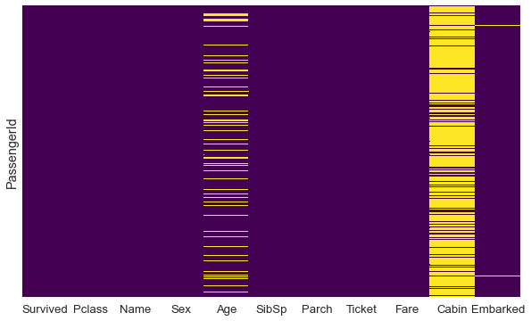

```python
plt.figure(figsize=(10,6))
sns.heatmap(train.isnull(),yticklabels=False,cbar=False,cmap='viridis');
```

Three features in the train data set with missing values were found: `Cabin` (77% missing), `Age` (20% missing) and `Embarked` (only 2 observations missing). They will be investigated further in the feature engineering section.

```python
missing_value(train)
```

|  | Total | Percentage |
| --- | --- | --- |
| Cabin | 687 | 77.104377 |
| Age | 177 | 19.865320 |
| Embarked | 2 | 0.224467 |

### Target feature: Survival

We will start with a check of the `Survived` column, a.k.a the target feature we will be trying to predict with the ML algorithms. A good start is with looking at the balance between the two classes in this feature.

```python
surv=train['Survived'].value_counts(normalize=True).mul(100).reset_index().rename(columns={'index': 'Survived','Survived':'percent'})
```

```python
surv.iloc[0,0] = 'No'
surv.iloc[1,0] = 'Yes'
```

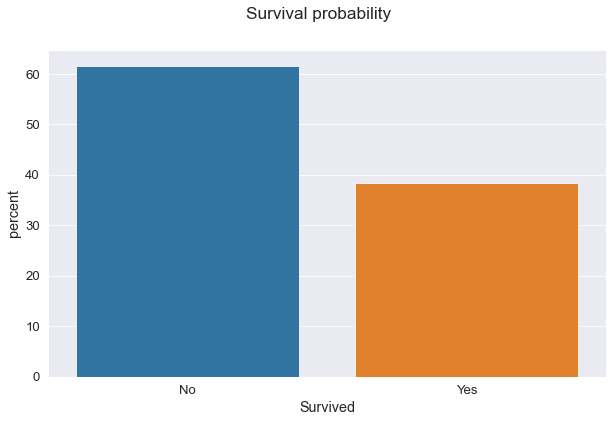

```python
plt.figure(figsize=(10,6))
sns.set_style('darkgrid')
sns.set_context('paper',font_scale=1.5)

plt.suptitle('Survival probability')
sns.barplot(x='Survived',y='percent',data=surv);
```

Over 60% of individuals didn't survived in the train data set.

Next we will look at the survival rate in the different features.

### Sex vs Survival rate

```python
sex=train.groupby('Sex')['Survived'].value_counts(normalize=True).mul(100).rename('percent').reset_index()
```

```python
sex
```

|  | Sex | Survived | percent |
| --- | --- | --- | --- |
| 0 | female | 1 | 74.203822 |
| 1 | female | 0 | 25.796178 |
| 2 | male | 0 | 81.109185 |
| 3 | male | 1 | 18.890815 |

```python
sex_dist = train['Sex'].value_counts(normalize=True).mul(100).reset_index().rename(columns={'index': 'Sex','Sex':'percent'})
```

```python
sex_dist
```

|  | Sex | percent |
| --- | --- | --- |
| 0 | male | 64.758698 |
| 1 | female | 35.241302 |

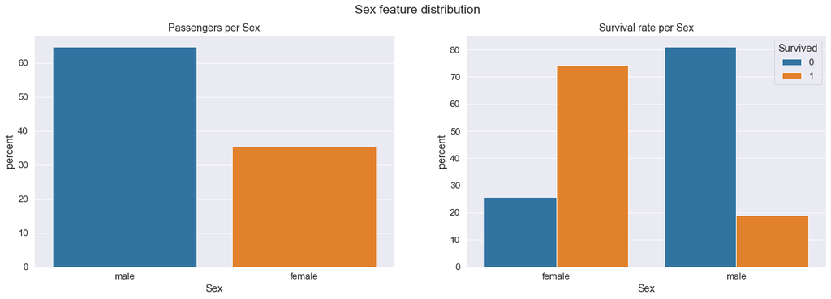

```python
fig, axs = plt.subplots(nrows=1,ncols=2,figsize=(20,6))
sns.set_style('darkgrid')
#sns.set_context('paper',font_scale=1)
plt.suptitle('Sex feature distribution')
axs[0].set_title('Passengers per Sex')
axs[1].set_title('Survival rate per Sex')

sns.barplot(ax=axs[0],x='Sex',y='percent',data=sex_dist)
sns.barplot(ax=axs[1],x='Sex',y='percent',hue='Survived',data=sex);
```

From the figure above becomes clear that male passengers in the train dataset represented over 60% of the individuals. Most of them did not survive the disaster (80%). It is also intersting to see in the figure below the age distribution of males and females. It is possible to note that passengers over 60 years were mainly males and that the distribution between classes of ages 0 to 60 are similar for both sex.

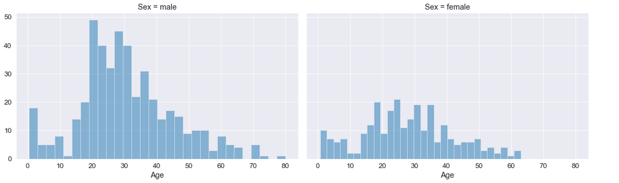

```python
sns.set_style('darkgrid')
#sns.set_context('paper',font_scale=2)

grid = sns.FacetGrid(data=train,
                     col='Sex',
                     margin_titles=True,height=5,aspect=1.6,legend_out=True,despine=False)

grid.map(plt.hist,'Age',alpha=0.5,bins=30)
grid.add_legend();
```

Now, if we split the age distribution one more level and look at the them across the `Survived` label, it seems that most male passengers over 60 did not survive the disaster.

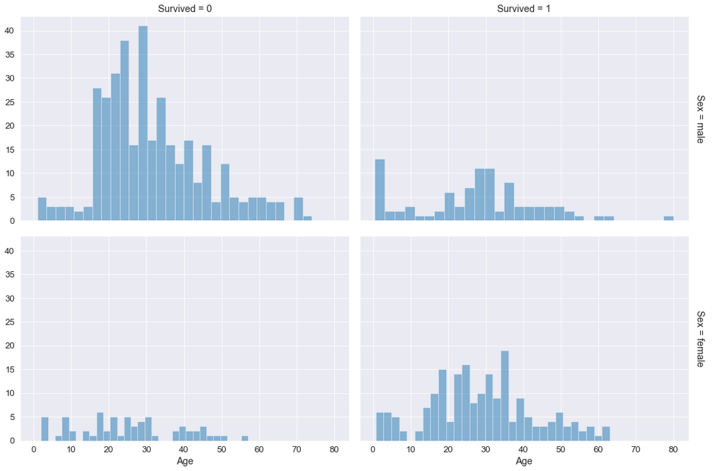

```python
sns.set_style('darkgrid')
#sns.set_context('paper',font_scale=1)

grid = sns.FacetGrid(data=train,
                     col='Survived',
                     row='Sex',
                     margin_titles=True,height=5,aspect=1.5,legend_out=True,despine=False)

grid.map(plt.hist,'Age',alpha=0.5,bins=30)
grid.add_legend();
```

### Pclass vs Survival rate

```python
pclass=train.groupby('Pclass')['Survived'].value_counts(normalize=True).mul(100).rename('percent').reset_index()
```

```python
pclass
```

|  | Pclass | Survived | percent |
| --- | --- | --- | --- |
| 0 | 1 | 1 | 62.962963 |
| 1 | 1 | 0 | 37.037037 |
| 2 | 2 | 0 | 52.717391 |
| 3 | 2 | 1 | 47.282609 |
| 4 | 3 | 0 | 75.763747 |
| 5 | 3 | 1 | 24.236253 |

```python
pclass_dist = train['Pclass'].value_counts(normalize=True).mul(100).reset_index().rename(columns={'index': 'Pclass','Pclass':'percent'})
```

```python
pclass_dist
```

|  | Pclass | percent |
| --- | --- | --- |
| 0 | 3 | 55.106622 |
| 1 | 1 | 24.242424 |
| 2 | 2 | 20.650954 |

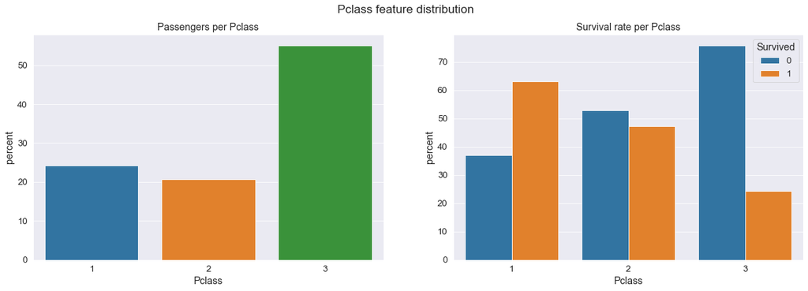

```python
fig, axs = plt.subplots(nrows=1,ncols=2,figsize=(20,6))
sns.set_style('darkgrid')
#sns.set_context('paper',font_scale=1)

plt.suptitle('Pclass feature distribution')
axs[0].set_title('Passengers per Pclass')
axs[1].set_title('Survival rate per Pclass')

sns.barplot(ax=axs[0],x='Pclass',y='percent',data=pclass_dist);
sns.barplot(ax=axs[1], x='Pclass',y='percent',data=pclass,hue='Survived');
```

Most of passenger were traveling in third class (~55%) and more than 75% of them did not survived. First class passengers were the ones with highes chance of survival (over 50%) while passengers on second class had similar chances of survival.

We could now add `Age` to the mix to investigate age structure in the different `Pclasses` to build a bit more out intuition on how the different features interact to each other.

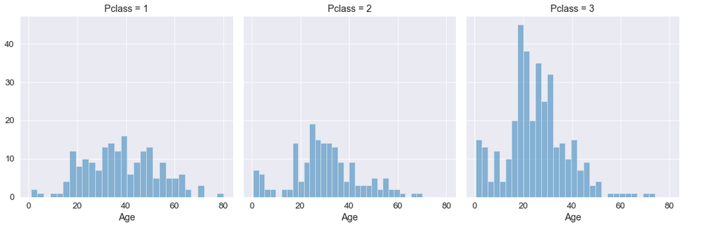

```python
sns.set_style('darkgrid')

grid = sns.FacetGrid(data=train,
                     #col='Survived',
                     col='Pclass',
                     margin_titles=True,height=5,aspect=1,legend_out=True,despine=False)

grid.map(plt.hist,'Age',alpha=0.5,bins=30)
grid.add_legend();
```

Most of youngsters were traveling on third class while the older passengers seem to be concentrated in first class. At leas we can't really see much passengers less than 20 years in first class as much as second and third.

Building up to an analysis of the `Age` sctructure per `Pclass` against `Survived` to comfirm the trend. Again, third classe with higher percetage of youngsters that did not survive can be inferred from the figure below.

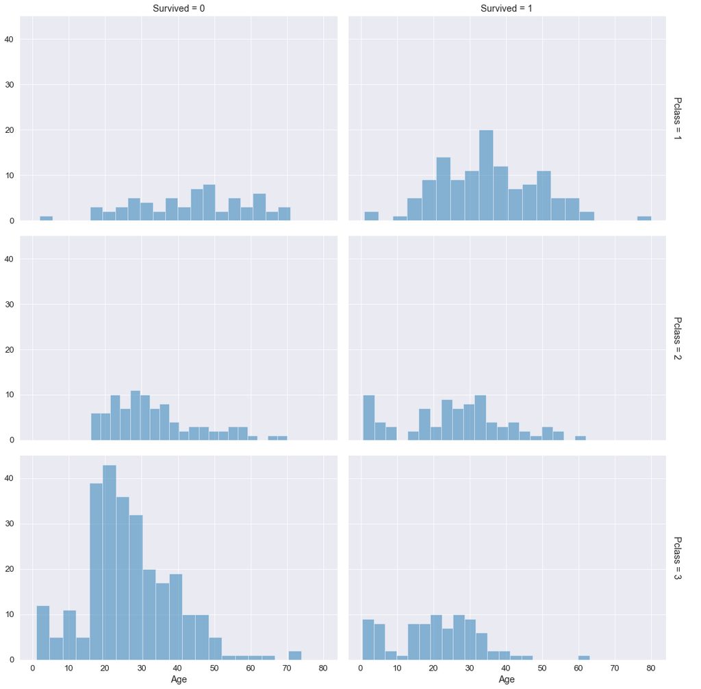

```python
sns.set_style('darkgrid')

grid = sns.FacetGrid(data=train,
                     col='Survived',
                     row='Pclass',
                     margin_titles=True,height=5,aspect=1.5,legend_out=True,despine=False)

grid.map(plt.hist,'Age',alpha=0.5,bins=20)
grid.add_legend();
```

Perhaps we should also look at the proportion of males and females per `Pclass`.

```python
sex_pclass=train.groupby('Pclass')['Sex'].value_counts(normalize=True).mul(100).rename('percent').reset_index()
```

```python
sex_pclass
```

|  | Pclass | Sex | percent |
| --- | --- | --- | --- |
| 0 | 1 | male | 56.481481 |
| 1 | 1 | female | 43.518519 |
| 2 | 2 | male | 58.695652 |
| 3 | 2 | female | 41.304348 |
| 4 | 3 | male | 70.672098 |
| 5 | 3 | female | 29.327902 |

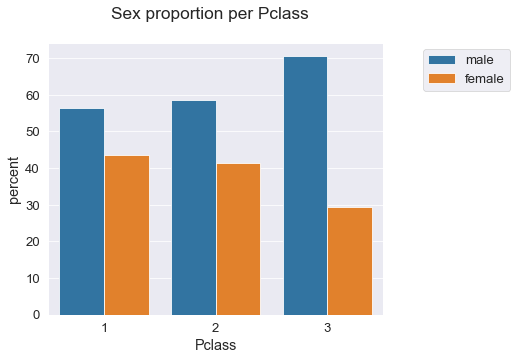

```python
fig, axs = plt.subplots(figsize=(6,5))
sns.set_style('darkgrid')
#sns.set_context('paper',font_scale=1)

plt.suptitle('Sex proportion per Pclass')

sns.barplot(x='Pclass',y='percent',hue='Sex',data=sex_pclass,ci=False)
plt.legend(bbox_to_anchor=(1.1,1));
```

As expected most of males were traveling on third class.

### Parch vs Survival rate

Continuing with our 'demographics' exploration we will have a look at `Parch` feature that contains the number of parents and children also on board the Titanic for each passenger.

```python
parch=train.groupby('Parch')['Survived'].value_counts(normalize=True).mul(100).rename('percent').reset_index()
```

```python
parch
```

|  | Parch | Survived | percent |
| --- | --- | --- | --- |
| 0 | 0 | 0 | 65.634218 |
| 1 | 0 | 1 | 34.365782 |
| 2 | 1 | 1 | 55.084746 |
| 3 | 1 | 0 | 44.915254 |
| 4 | 2 | 0 | 50.000000 |
| 5 | 2 | 1 | 50.000000 |
| 6 | 3 | 1 | 60.000000 |
| 7 | 3 | 0 | 40.000000 |
| 8 | 4 | 0 | 100.000000 |
| 9 | 5 | 0 | 80.000000 |
| 10 | 5 | 1 | 20.000000 |
| 11 | 6 | 0 | 100.000000 |

```python
parch_dist = train['Parch'].value_counts(normalize=True).mul(100).reset_index().rename(columns={'index': 'Parch','Parch':'percent'})
```

```python
parch_dist
```

|  | Parch | percent |
| --- | --- | --- |
| 0 | 0 | 76.094276 |
| 1 | 1 | 13.243547 |
| 2 | 2 | 8.978676 |
| 3 | 3 | 0.561167 |
| 4 | 5 | 0.561167 |
| 5 | 4 | 0.448934 |
| 6 | 6 | 0.112233 |

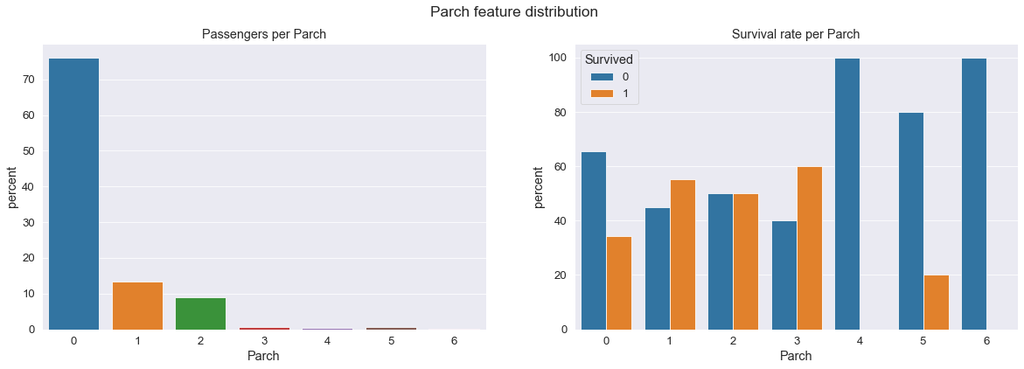

```python
fig, axs = plt.subplots(nrows=1,ncols=2,figsize=(20,6))
sns.set_style('darkgrid')
#sns.set_context('paper',font_scale=1)

plt.suptitle('Parch feature distribution')
axs[0].set_title('Passengers per Parch')
axs[1].set_title('Survival rate per Parch')

sns.barplot(ax=axs[0],x='Parch',y='percent',data=parch_dist);
sns.barplot(ax=axs[1], x='Parch',y='percent',data=parch,hue='Survived');
```

More than 75% of the passengers had no parents nor children on board the Titanic and over 65% of them did not surivive. However it is important to note that passengers with `Parch` over 4 had even lower survival rate.

### SibSp vs Survival rate

```python
sibsp=train.groupby('SibSp')['Survived'].value_counts(normalize=True).mul(100).rename('percent').reset_index()
```

```python
sibsp
```

|  | SibSp | Survived | percent |
| --- | --- | --- | --- |
| 0 | 0 | 0 | 65.460526 |
| 1 | 0 | 1 | 34.539474 |
| 2 | 1 | 1 | 53.588517 |
| 3 | 1 | 0 | 46.411483 |
| 4 | 2 | 0 | 53.571429 |
| 5 | 2 | 1 | 46.428571 |
| 6 | 3 | 0 | 75.000000 |
| 7 | 3 | 1 | 25.000000 |
| 8 | 4 | 0 | 83.333333 |
| 9 | 4 | 1 | 16.666667 |
| 10 | 5 | 0 | 100.000000 |
| 11 | 8 | 0 | 100.000000 |

```python
sibsp_dist = train['SibSp'].value_counts(normalize=True).mul(100).reset_index().rename(columns={'index': 'SibSp','SibSp':'percent'})
```

```python
sibsp_dist
```

|  | SibSp | percent |
| --- | --- | --- |
| 0 | 0 | 68.237935 |
| 1 | 1 | 23.456790 |
| 2 | 2 | 3.142536 |
| 3 | 4 | 2.020202 |
| 4 | 3 | 1.795735 |
| 5 | 8 | 0.785634 |
| 6 | 5 | 0.561167 |

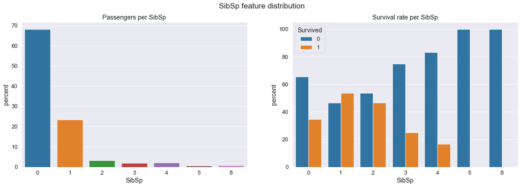

```python
fig, axs = plt.subplots(nrows=1,ncols=2,figsize=(20,6))
sns.set_style('darkgrid')
#sns.set_context('paper',font_scale=1)

plt.suptitle('SibSp feature distribution')
axs[0].set_title('Passengers per SibSp')
axs[1].set_title('Survival rate per SibSp')

sns.barplot(ax=axs[0],x='SibSp',y='percent',data=sibsp_dist);
sns.barplot(ax=axs[1], x='SibSp',y='percent',data=sibsp,hue='Survived');
```

### Combining Parch and SibSp

As a test we will use the features `Parch`and `SibSp` and unite them in a new feature called `Family` where we will classify passengers as travelling with family members or not.

```python
def sib_family(row):
    if row['SibSp'] > 0:
        return 1
    else:
        return 0
train['SibSp'] = train.apply(lambda row: sib_family(row),axis=1)
```

```python
def par_family(row):
    if row['Parch'] > 0:
        return 1
    else:
        return 0
train['Parch'] = train.apply(lambda row: par_family(row),axis=1)
```

```python
train.head()
```

| PassengerId | Survived | Pclass | Name | Sex | Age | SibSp | Parch | Ticket | Fare | Cabin | Embarked |
| --- | --- | --- | --- | --- | --- | --- | --- | --- | --- | --- | --- |
| 1 | 0 | 3 | Braund, Mr. Owen Harris | male | 22.0 | 1 | 0 | A/5 21171 | 7.2500 | NaN | S |
| 2 | 1 | 1 | Cumings, Mrs. John Bradley (Florence Briggs Th... | female | 38.0 | 1 | 0 | PC 17599 | 71.2833 | C85 | C |
| 3 | 1 | 3 | Heikkinen, Miss. Laina | female | 26.0 | 0 | 0 | STON/O2. 3101282 | 7.9250 | NaN | S |
| 4 | 1 | 1 | Futrelle, Mrs. Jacques Heath (Lily May Peel) | female | 35.0 | 1 | 0 | 113803 | 53.1000 | C123 | S |
| 5 | 0 | 3 | Allen, Mr. William Henry | male | 35.0 | 0 | 0 | 373450 | 8.0500 | NaN | S |

```python
train['Family'] = train['SibSp'] + train['Parch']
```

```python
train.head()
```

| PassengerId | Survived | Pclass | Name | Sex | Age | SibSp | Parch | Ticket | Fare | Cabin | Embarked | Family |
| --- | --- | --- | --- | --- | --- | --- | --- | --- | --- | --- | --- | --- |
| 1 | 0 | 3 | Braund, Mr. Owen Harris | male | 22.0 | 1 | 0 | A/5 21171 | 7.2500 | NaN | S | 1 |
| 2 | 1 | 1 | Cumings, Mrs. John Bradley (Florence Briggs Th... | female | 38.0 | 1 | 0 | PC 17599 | 71.2833 | C85 | C | 1 |
| 3 | 1 | 3 | Heikkinen, Miss. Laina | female | 26.0 | 0 | 0 | STON/O2. 3101282 | 7.9250 | NaN | S | 0 |
| 4 | 1 | 1 | Futrelle, Mrs. Jacques Heath (Lily May Peel) | female | 35.0 | 1 | 0 | 113803 | 53.1000 | C123 | S | 1 |
| 5 | 0 | 3 | Allen, Mr. William Henry | male | 35.0 | 0 | 0 | 373450 | 8.0500 | NaN | S | 0 |

```python
def family(row):
    if row['Family'] > 0:
        return 1
    else:
        return 0
train['Family'] = train.apply(lambda row: family(row),axis=1)
```

```python
train.head()
```

| PassengerId | Survived | Pclass | Name | Sex | Age | SibSp | Parch | Ticket | Fare | Cabin | Embarked | Family |
| --- | --- | --- | --- | --- | --- | --- | --- | --- | --- | --- | --- | --- |
| 1 | 0 | 3 | Braund, Mr. Owen Harris | male | 22.0 | 1 | 0 | A/5 21171 | 7.2500 | NaN | S | 1 |
| 2 | 1 | 1 | Cumings, Mrs. John Bradley (Florence Briggs Th... | female | 38.0 | 1 | 0 | PC 17599 | 71.2833 | C85 | C | 1 |
| 3 | 1 | 3 | Heikkinen, Miss. Laina | female | 26.0 | 0 | 0 | STON/O2. 3101282 | 7.9250 | NaN | S | 0 |
| 4 | 1 | 1 | Futrelle, Mrs. Jacques Heath (Lily May Peel) | female | 35.0 | 1 | 0 | 113803 | 53.1000 | C123 | S | 1 |
| 5 | 0 | 3 | Allen, Mr. William Henry | male | 35.0 | 0 | 0 | 373450 | 8.0500 | NaN | S | 0 |

```python
train['Family'].value_counts()
```

```
0    537
1    354
Name: Family, dtype: int64
```

```python
fam_dist = train['Family'].value_counts(normalize=True).mul(100).reset_index().rename(columns={'index': 'Family','Family':'percent'})
```

```python
fam_dist
```

|  | Family | percent |
| --- | --- | --- |
| 0 | 0 | 60.26936 |
| 1 | 1 | 39.73064 |

```python
fam = train.groupby('Family')['Survived'].value_counts(normalize=True).mul(100).rename('percent').reset_index()
```

```python
fam
```

|  | Family | Survived | percent |
| --- | --- | --- | --- |
| 0 | 0 | 0 | 69.646182 |
| 1 | 0 | 1 | 30.353818 |
| 2 | 1 | 1 | 50.564972 |
| 3 | 1 | 0 | 49.435028 |

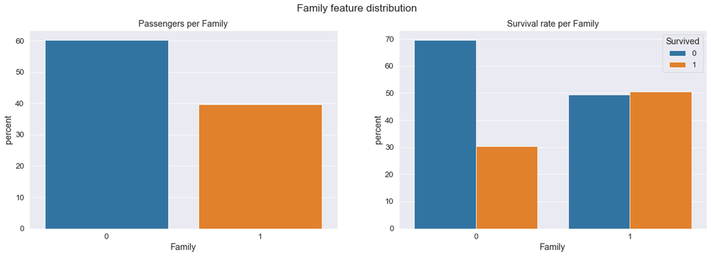

```python
fig, axs = plt.subplots(nrows=1,ncols=2,figsize=(20,6))
sns.set_style('darkgrid')
#sns.set_context('paper',font_scale=1)

plt.suptitle('Family feature distribution')
axs[0].set_title('Passengers per Family')
axs[1].set_title('Survival rate per Family')

sns.barplot(ax=axs[0],x='Family',y='percent',data=fam_dist);
sns.barplot(ax=axs[1], x='Family',y='percent',data=fam,hue='Survived');
```

### Summarizing demographics analysis

Some good intuition is already built from the data exploration on the demographics of Titanic passengers done so far. Before we continue let's summarize what've lerned so far:

- Most of passengers did not survived
- Most of passengers were men
- Most of passengers were young under 40 years old (men and women)
- Most of passengers were traveling in 3rd class (men and women)
- Most passemger were traveling alone
- Chance of survival seem to be related to number of family members traveling together

Now we will look at the `Embarkaed` feature, representing the ports were the passengeres embarqued Titanic: Cherbourg (C), Queenstown (Q), Southampton (S)

### Embarked vs Survival rate

```python
embkd = train.groupby('Embarked')['Survived'].value_counts(normalize=True).mul(100).rename('percent').reset_index()
```

```python
embkd
```

|  | Embarked | Survived | percent |
| --- | --- | --- | --- |
| 0 | C | 1 | 55.357143 |
| 1 | C | 0 | 44.642857 |
| 2 | Q | 0 | 61.038961 |
| 3 | Q | 1 | 38.961039 |
| 4 | S | 0 | 66.304348 |
| 5 | S | 1 | 33.695652 |

```python
embkd_dist = train['Embarked'].value_counts(normalize=True).mul(100).reset_index().rename(columns={'index': 'Embarked','Embarked':'percent'})
```

```python
embkd_dist
```

|  | Embarked | percent |
| --- | --- | --- |
| 0 | S | 72.440945 |
| 1 | C | 18.897638 |
| 2 | Q | 8.661417 |

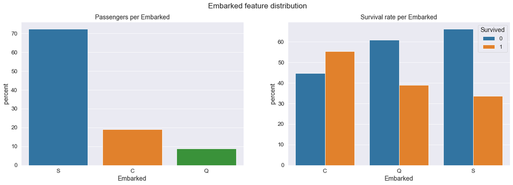

```python
fig, axs = plt.subplots(nrows=1,ncols=2,figsize=(20,6))
sns.set_style('darkgrid')
#sns.set_context('paper',font_scale=1)

plt.suptitle('Embarked feature distribution')
axs[0].set_title('Passengers per Embarked')
axs[1].set_title('Survival rate per Embarked')

sns.barplot(ax=axs[0],x='Embarked',y='percent',data=embkd_dist);
sns.barplot(ax=axs[1], x='Embarked',y='percent',data=embkd,hue='Survived');
```

Most passengers got on board in Southampton and passengers that embarked in Cherbourg had higher survival rate.

### Fare vs Pclass

Last but not least, the `Fare` feature will be investigated. We want to look into the relationship between fare and `Pclass` as I would expect some sort of pricing difference.

```python
fare = train.groupby('Pclass')['Fare'].describe()
```

```python
fare.transpose()
```

| Pclass | 1 | 2 | 3 |
| --- | --- | --- | --- |
| count | 216.000000 | 184.000000 | 491.000000 |
| mean | 84.154687 | 20.662183 | 13.675550 |
| std | 78.380373 | 13.417399 | 11.778142 |
| min | 0.000000 | 0.000000 | 0.000000 |
| 25% | 30.923950 | 13.000000 | 7.750000 |
| 50% | 60.287500 | 14.250000 | 8.050000 |
| 75% | 93.500000 | 26.000000 | 15.500000 |
| max | 512.329200 | 73.500000 | 69.550000 |

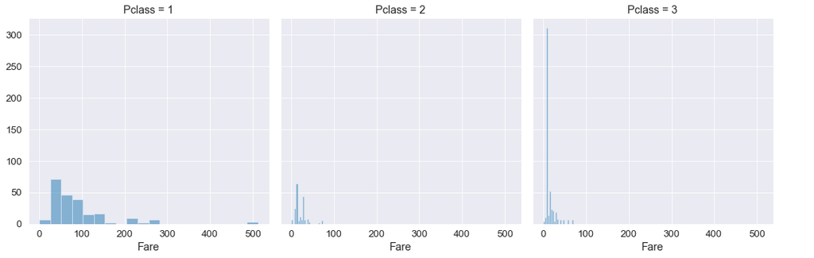

```python
sns.set_style('darkgrid')

grid = sns.FacetGrid(data=train,
                     #row='Embarked',
                     col='Pclass',
                     margin_titles=True,height=5,aspect=1,legend_out=True,despine=False)

grid.map(plt.hist,'Fare',alpha=.5,bins=20)
grid.add_legend();
```

It is clear that there a significant price difference for the different classes onboard and it seems that the features `Fare`and `Pclass` are redundant.

### Cabin vs Survival rate

Looking now at the `Cabin` feature where 77% of the data is missing.

```python
train['Cabin'].unique()
```

```
array([nan, 'C85', 'C123', 'E46', 'G6', 'C103', 'D56', 'A6',
       'C23 C25 C27', 'B78', 'D33', 'B30', 'C52', 'B28', 'C83', 'F33',
       'F G73', 'E31', 'A5', 'D10 D12', 'D26', 'C110', 'B58 B60', 'E101',
       'F E69', 'D47', 'B86', 'F2', 'C2', 'E33', 'B19', 'A7', 'C49', 'F4',
       'A32', 'B4', 'B80', 'A31', 'D36', 'D15', 'C93', 'C78', 'D35',
       'C87', 'B77', 'E67', 'B94', 'C125', 'C99', 'C118', 'D7', 'A19',
       'B49', 'D', 'C22 C26', 'C106', 'C65', 'E36', 'C54',
       'B57 B59 B63 B66', 'C7', 'E34', 'C32', 'B18', 'C124', 'C91', 'E40',
       'T', 'C128', 'D37', 'B35', 'E50', 'C82', 'B96 B98', 'E10', 'E44',
       'A34', 'C104', 'C111', 'C92', 'E38', 'D21', 'E12', 'E63', 'A14',
       'B37', 'C30', 'D20', 'B79', 'E25', 'D46', 'B73', 'C95', 'B38',
       'B39', 'B22', 'C86', 'C70', 'A16', 'C101', 'C68', 'A10', 'E68',
       'B41', 'A20', 'D19', 'D50', 'D9', 'A23', 'B50', 'A26', 'D48',
       'E58', 'C126', 'B71', 'B51 B53 B55', 'D49', 'B5', 'B20', 'F G63',
       'C62 C64', 'E24', 'C90', 'C45', 'E8', 'B101', 'D45', 'C46', 'D30',
       'E121', 'D11', 'E77', 'F38', 'B3', 'D6', 'B82 B84', 'D17', 'A36',
       'B102', 'B69', 'E49', 'C47', 'D28', 'E17', 'A24', 'C50', 'B42',
       'C148'], dtype=object)
```

```python
# Fill na with letter 'U' from Unknown to be used for analysis against Survived
train['Cabin'].fillna('U',inplace=True)
```

```python
cabin_letter = train.copy()
```

```python
cabin_letter['cabin_letter'] = cabin_letter['Cabin'].str[0]
```

```python
c_letter = cabin_letter.groupby('cabin_letter')['Survived'].value_counts(normalize=True).mul(100).rename('percent').reset_index()
```

```python
c_letter
```

|  | cabin_letter | Survived | percent |
| --- | --- | --- | --- |
| 0 | A | 0 | 53.333333 |
| 1 | A | 1 | 46.666667 |
| 2 | B | 1 | 74.468085 |
| 3 | B | 0 | 25.531915 |
| 4 | C | 1 | 59.322034 |
| 5 | C | 0 | 40.677966 |
| 6 | D | 1 | 75.757576 |
| 7 | D | 0 | 24.242424 |
| 8 | E | 1 | 75.000000 |
| 9 | E | 0 | 25.000000 |
| 10 | F | 1 | 61.538462 |
| 11 | F | 0 | 38.461538 |
| 12 | G | 0 | 50.000000 |
| 13 | G | 1 | 50.000000 |
| 14 | T | 0 | 100.000000 |
| 15 | U | 0 | 70.014556 |
| 16 | U | 1 | 29.985444 |

```python
c_letter_dist = cabin_letter['cabin_letter'].value_counts(normalize=True).mul(100).reset_index().rename(columns={'index': 'cabin_letter','cabin_letter':'percent'})
```

```python
c_letter_dist
```

|  | cabin_letter | percent |
| --- | --- | --- |
| 0 | U | 77.104377 |
| 1 | C | 6.621773 |
| 2 | B | 5.274972 |
| 3 | D | 3.703704 |
| 4 | E | 3.591470 |
| 5 | A | 1.683502 |
| 6 | F | 1.459035 |
| 7 | G | 0.448934 |
| 8 | T | 0.112233 |

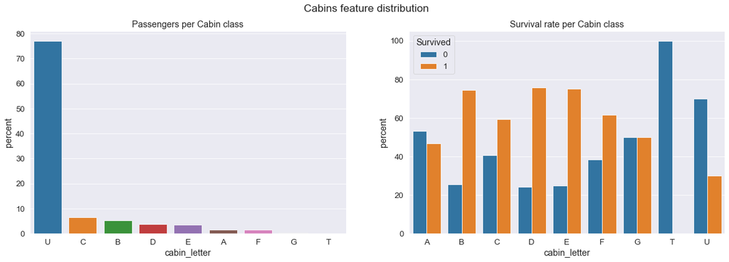

```python
fig, axs = plt.subplots(nrows=1,ncols=2,figsize=(20,6))
sns.set_style('darkgrid')
#sns.set_context('paper',font_scale=1)

plt.suptitle('Cabins feature distribution')
axs[0].set_title('Passengers per Cabin class')
axs[1].set_title('Survival rate per Cabin class')

sns.barplot(ax=axs[0],x='cabin_letter',y='percent',data=c_letter_dist);
sns.barplot(ax=axs[1], x='cabin_letter',y='percent',data=c_letter,hue='Survived');
```

It seems `Cabin` is a good candidate to be also engineered into 2 single classes (known and unkown) since it seems that passagers with known cabins had more change of surviving.

### Name vs Survival rate

Intuitively your name should not increaseor decrease your chance of survival but the title in the name might be of some use. We will extract the title and check it against the survival rate.

```python
# check unique titles
train['Name'].str.extract(' ([A-Za-z]+)\.', expand=False).value_counts()
```

```
Mr          517
Miss        182
Mrs         125
Master       40
Dr            7
Rev           6
Mlle          2
Major         2
Col           2
Lady          1
Capt          1
Don           1
Countess      1
Mme           1
Sir           1
Ms            1
Jonkheer      1
Name: Name, dtype: int64
```

```python
c = train['Name']
```

```python
c = c.tolist()
```

```python
d = []

def ttle(name):
    for i in c:
        if 'Mr.' in i:
            d.append('Mr')
        elif 'Dr.' in i:
            d.append('Mr')
        elif 'Rev.' in i:
            d.append('Mr')
        elif 'Col.' in i:
            d.append('Mr')
        elif 'Capt.' in i:
            d.append('Mr')
        elif 'Major.' in i:
            d.append('Mr')
        elif 'Don.' in i:
            d.append('Mr')
        elif 'Sir.' in i:
            d.append('Mr')

        elif 'Master.' in i:
            d.append('Master')

        elif 'Miss.' in i:
            d.append('Miss')
        elif 'Mlle.' in i:
            d.append('Miss')
        elif 'Mme.' in i:
            d.append('Miss')
        elif 'Ms.' in i:
            d.append('Miss')

        elif 'Mrs.' in i:
            d.append('Mrs')
        elif 'Countess.' in i:
            d.append('Mrs')
        elif 'Lady.' in i:
            d.append('Mrs')
        elif 'Dona.' in i:
            d.append('Mrs')

ttle(c)
```

```python
d2 = pd.Series(d)
```

```python
d2.value_counts()
```

```
Mr        537
Miss      186
Mrs       127
Master     40
dtype: int64
```

```python
train['Title'] = d2
```

```python
train.head()
```

| PassengerId | Survived | Pclass | Name | Sex | Age | SibSp | Parch | Ticket | Fare | Cabin | Embarked | Family | Title |
| --- | --- | --- | --- | --- | --- | --- | --- | --- | --- | --- | --- | --- | --- |
| 1 | 0 | 3 | Braund, Mr. Owen Harris | male | 22.0 | 1 | 0 | A/5 21171 | 7.2500 | U | S | 1 | Mrs |
| 2 | 1 | 1 | Cumings, Mrs. John Bradley (Florence Briggs Th... | female | 38.0 | 1 | 0 | PC 17599 | 71.2833 | C85 | C | 1 | Miss |
| 3 | 1 | 3 | Heikkinen, Miss. Laina | female | 26.0 | 0 | 0 | STON/O2. 3101282 | 7.9250 | U | S | 0 | Mrs |
| 4 | 1 | 1 | Futrelle, Mrs. Jacques Heath (Lily May Peel) | female | 35.0 | 1 | 0 | 113803 | 53.1000 | C123 | S | 1 | Mr |
| 5 | 0 | 3 | Allen, Mr. William Henry | male | 35.0 | 0 | 0 | 373450 | 8.0500 | U | S | 0 | Mr |

```python
title_dist = train['Title'].value_counts(normalize=True).mul(100).reset_index().rename(columns={'index': 'Title','Title':'percent'})
```

```python
title_dist
```

|  | Title | percent |
| --- | --- | --- |
| 0 | Mr | 60.292463 |
| 1 | Miss | 20.922385 |
| 2 | Mrs | 14.285714 |
| 3 | Master | 4.499438 |

```python
title = train.groupby('Title')['Survived'].value_counts(normalize=True).mul(100).rename('percent').reset_index()
```

```python
title
```

|  | Title | Survived | percent |
| --- | --- | --- | --- |
| 0 | Master | 0 | 67.500000 |
| 1 | Master | 1 | 32.500000 |
| 2 | Miss | 0 | 64.516129 |
| 3 | Miss | 1 | 35.483871 |
| 4 | Mr | 0 | 60.634328 |
| 5 | Mr | 1 | 39.365672 |
| 6 | Mrs | 0 | 59.842520 |
| 7 | Mrs | 1 | 40.157480 |

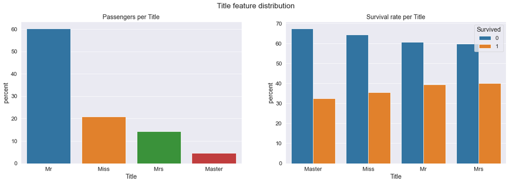

```python
fig, axs = plt.subplots(nrows=1,ncols=2,figsize=(20,6))
sns.set_style('darkgrid')
#sns.set_context('paper',font_scale=1)

plt.suptitle('Title feature distribution')
axs[0].set_title('Passengers per Title')
axs[1].set_title('Survival rate per Title')

sns.barplot(ax=axs[0],x='Title',y='percent',data=title_dist);
sns.barplot(ax=axs[1], x='Title',y='percent',data=title,hue='Survived');
```

```python
train.head()
```

| PassengerId | Survived | Pclass | Name | Sex | Age | SibSp | Parch | Ticket | Fare | Cabin | Embarked | Family | Title |
| --- | --- | --- | --- | --- | --- | --- | --- | --- | --- | --- | --- | --- | --- |
| 1 | 0 | 3 | Braund, Mr. Owen Harris | male | 22.0 | 1 | 0 | A/5 21171 | 7.2500 | U | S | 1 | Mrs |
| 2 | 1 | 1 | Cumings, Mrs. John Bradley (Florence Briggs Th... | female | 38.0 | 1 | 0 | PC 17599 | 71.2833 | C85 | C | 1 | Miss |
| 3 | 1 | 3 | Heikkinen, Miss. Laina | female | 26.0 | 0 | 0 | STON/O2. 3101282 | 7.9250 | U | S | 0 | Mrs |
| 4 | 1 | 1 | Futrelle, Mrs. Jacques Heath (Lily May Peel) | female | 35.0 | 1 | 0 | 113803 | 53.1000 | C123 | S | 1 | Mr |
| 5 | 0 | 3 | Allen, Mr. William Henry | male | 35.0 | 0 | 0 | 373450 | 8.0500 | U | S | 0 | Mr |

We will now have a look at the corrrelation between categorical features to try to improve our understanding on how they can 'explain' each other and help us make decisions on which one we should keep, engineer or drop.

```python
from dython.nominal import associations
```

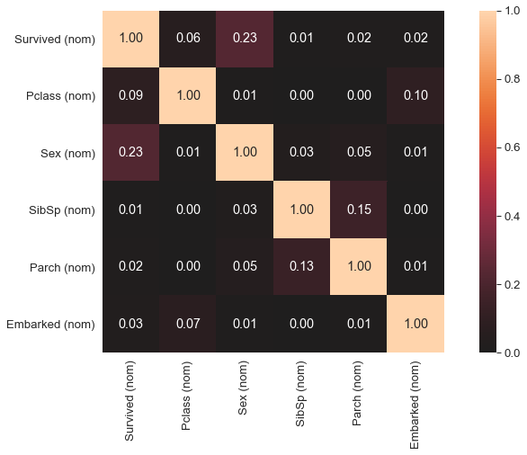

```python
# sns.set_context('paper',font_scale=1.2)

cat_cols = ['Survived', 'Pclass', 'Sex', 'SibSp',
            'Parch', 'Cabin', 'Embarked']

fig1 = associations(train.drop(['Name','Ticket','Age','Fare','Family','Cabin','Title'],axis=1),
                    figsize=(14,7),
                    theil_u=True, nominal_columns=cat_cols,
                    #title='Fig. 1. Associations between features.',
                    mark_columns=True);
```

Let's have a quick look at the test data set for missing data only.

## Test dataset

```python
test = pd.read_csv('test.csv')
ids_test = test['PassengerId'].values
```

```python
test.head()
```

|  | PassengerId | Pclass | Name | Sex | Age | SibSp | Parch | Ticket | Fare | Cabin | Embarked |
| --- | --- | --- | --- | --- | --- | --- | --- | --- | --- | --- | --- |
| 0 | 892 | 3 | Kelly, Mr. James | male | 34.5 | 0 | 0 | 330911 | 7.8292 | NaN | Q |
| 1 | 893 | 3 | Wilkes, Mrs. James (Ellen Needs) | female | 47.0 | 1 | 0 | 363272 | 7.0000 | NaN | S |
| 2 | 894 | 2 | Myles, Mr. Thomas Francis | male | 62.0 | 0 | 0 | 240276 | 9.6875 | NaN | Q |
| 3 | 895 | 3 | Wirz, Mr. Albert | male | 27.0 | 0 | 0 | 315154 | 8.6625 | NaN | S |
| 4 | 896 | 3 | Hirvonen, Mrs. Alexander (Helga E Lindqvist) | female | 22.0 | 1 | 1 | 3101298 | 12.2875 | NaN | S |

```python
print(f'There are {test.shape[0]} rows in the data frame')
print(f'There are {test.shape[1]} columns in the data frame')
```

```
There are 418 rows in the data frame
There are 11 columns in the data frame
```

```python
test.info()
```

```
<class 'pandas.core.frame.DataFrame'>
RangeIndex: 418 entries, 0 to 417
Data columns (total 11 columns):
 #   Column       Non-Null Count  Dtype
---  ------       --------------  -----
 0   PassengerId  418 non-null    int64
 1   Pclass       418 non-null    int64
 2   Name         418 non-null    object
 3   Sex          418 non-null    object
 4   Age          332 non-null    float64
 5   SibSp        418 non-null    int64
 6   Parch        418 non-null    int64
 7   Ticket       418 non-null    object
 8   Fare         417 non-null    float64
 9   Cabin        91 non-null     object
 10  Embarked     418 non-null    object
dtypes: float64(2), int64(4), object(5)
memory usage: 36.0+ KB
```

### Checking for missing values

```python
test.isnull().values.any()
```

```
True
```

```python
test.isnull().sum()
```

```
PassengerId      0
Pclass           0
Name             0
Sex              0
Age             86
SibSp            0
Parch            0
Ticket           0
Fare             1
Cabin          327
Embarked         0
dtype: int64
```

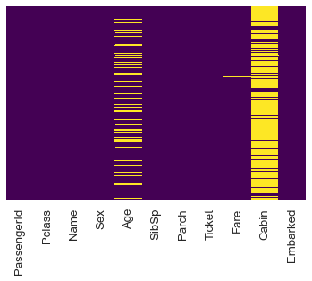

```python
sns.heatmap(test.isnull(),yticklabels=False,cbar=False,cmap='viridis')
```

Cabin, Fare and Age have missig values. That will be rectified in the next section

# Feature engineering and preparation

```python
# Combining test and train datasets and setting
train = pd.read_csv('train.csv')
test = pd.read_csv('test.csv')
full_set = pd.concat([train,test],axis=0).reset_index(drop=True)
```

```python
# Set 'PassengerId' as index for future split
full_set.set_index(keys='PassengerId',inplace=True)
```

```python
full_set.tail()
```

| PassengerId | Survived | Pclass | Name | Sex | Age | SibSp | Parch | Ticket | Fare | Cabin | Embarked |
| --- | --- | --- | --- | --- | --- | --- | --- | --- | --- | --- | --- |
| 1305 | NaN | 3 | Spector, Mr. Woolf | male | NaN | 0 | 0 | A.5. 3236 | 8.0500 | NaN | S |
| 1306 | NaN | 1 | Oliva y Ocana, Dona. Fermina | female | 39.0 | 0 | 0 | PC 17758 | 108.9000 | C105 | C |
| 1307 | NaN | 3 | Saether, Mr. Simon Sivertsen | male | 38.5 | 0 | 0 | SOTON/O.Q. 3101262 | 7.2500 | NaN | S |
| 1308 | NaN | 3 | Ware, Mr. Frederick | male | NaN | 0 | 0 | 359309 | 8.0500 | NaN | S |
| 1309 | NaN | 3 | Peter, Master. Michael J | male | NaN | 1 | 1 | 2668 | 22.3583 | NaN | C |

Function to check missing values and return a data frame with a summary

```python
def missing_value(df):
    number = df.isnull().sum().sort_values(ascending=False)
    number = number[number > 0]
    percentage = df.isnull().sum() *100 / df.shape[0]
    percentage = percentage[percentage > 0].sort_values(ascending=False)
    return  pd.concat([number,percentage],keys=["Total","Percentage"],axis=1)
missing_value(full_set.drop('Survived',axis=1))
```

|  | Total | Percentage |
| --- | --- | --- |
| Cabin | 1014 | 77.463713 |
| Age | 263 | 20.091673 |
| Embarked | 2 | 0.152788 |
| Fare | 1 | 0.076394 |

### Cabin feature

We decided to group the cabins into 'known' and 'unknown' classes:

- all uknown cabin data will be 0
- all known cabin data will be 1

```python
full_set['Cabin'].fillna(0,inplace=True)
```

```python
def cab_map(row):
    if row['Cabin'] != 0:
        return 1
    else:
        return row['Cabin']
```

```python
full_set['Cabin'] = full_set.apply(lambda row: cab_map(row),axis=1)
```

```python
full_set['Cabin'].head()
```

```
PassengerId
1    0
2    1
3    0
4    1
5    0
Name: Cabin, dtype: int64
```

### Age feature

From the EDA above we built an intuiton that age seem to be well connected to the different `Pclass` on board Titanic maybe as a result of the difference in the ticket price across the classes. One could assume than younger people would have less money than older, better established man, and therefore would travel on third class instead. We decided to give another check to confirm this theory. See below:

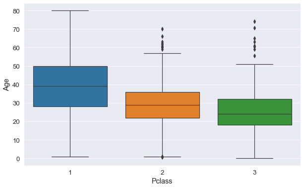

```python
plt.figure(figsize=(10,6))
sns.boxplot(x='Pclass',y='Age',data=full_set);
```

Above we can see the boxplot distribution of `Age` per `Pclass` and it does seem that the average age distribution is different for each class.

Let's have a look at a kde plot to double check the change:

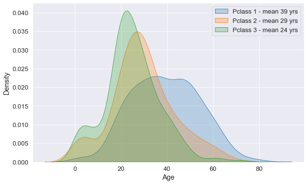

```python
fig, axs = plt.subplots(figsize=(10,6))

sns.kdeplot(full_set['Age'][full_set['Pclass'] == 1],legend=True,label='Pclass 1 - mean 39 yrs',shade=True)
sns.kdeplot(full_set['Age'][full_set['Pclass'] == 2],legend=True,label='Pclass 2 - mean 29 yrs',shade=True)
sns.kdeplot(full_set['Age'][full_set['Pclass'] == 3],legend=True,label='Pclass 3 - mean 24 yrs',shade=True)
plt.legend();
```

```python
full_set.groupby('Pclass')['Age'].describe().transpose()
```

| Pclass | 1 | 2 | 3 |
| --- | --- | --- | --- |
| count | 284.000000 | 261.000000 | 501.000000 |
| mean | 39.159930 | 29.506705 | 24.816367 |
| std | 14.548028 | 13.638627 | 11.958202 |
| min | 0.920000 | 0.670000 | 0.170000 |
| 25% | 28.000000 | 22.000000 | 18.000000 |
| 50% | 39.000000 | 29.000000 | 24.000000 |
| 75% | 50.000000 | 36.000000 | 32.000000 |
| max | 80.000000 | 70.000000 | 74.000000 |

```python
def impute_age(cols):
    Age = cols[0]
    Pclass = cols[1]

    if pd.isnull(Age):

        if Pclass == 1:
            return 39

        elif Pclass == 2:
            return 29

        else:
            return 24

    else:
        return Age
```

```python
full_set['Age'] = full_set[['Age','Pclass']].apply(impute_age,axis=1)
```

### Embarked feature

Only 2 missing data here. Checking the passengers individually.

```python
full_set[full_set['Embarked'].isnull()]
```

| PassengerId | Survived | Pclass | Name | Sex | Age | SibSp | Parch | Ticket | Fare | Cabin | Embarked |
| --- | --- | --- | --- | --- | --- | --- | --- | --- | --- | --- | --- |
| 62 | 1.0 | 1 | Icard, Miss. Amelie | female | 38.0 | 0 | 0 | 113572 | 80.0 | 1 | NaN |
| 830 | 1.0 | 1 | Stone, Mrs. George Nelson (Martha Evelyn) | female | 62.0 | 0 | 0 | 113572 | 80.0 | 1 | NaN |

Filtering the full data set and counting of all passangers with known cabin that paid 80 or more for the ticked:

```python
sim_embarked = full_set[(full_set.Pclass == 1) &
                            (full_set['Cabin'] == 1) &
                            (full_set['Fare'] >= 80)]
sim_embarked['Embarked'].value_counts()
```

```
C    53
S    43
Q     3
Name: Embarked, dtype: int64
```

Decided to impute these 2 individuals as 'C'

```python
full_set['Embarked'].fillna('C',inplace=True)
```

### Fare feature

Only 1 individual that we don't know the `Fare` paid.

```python
full_set[full_set['Fare'].isnull()]
```

| PassengerId | Survived | Pclass | Name | Sex | Age | SibSp | Parch | Ticket | Fare | Cabin | Embarked |
| --- | --- | --- | --- | --- | --- | --- | --- | --- | --- | --- | --- |
| 1044 | NaN | 3 | Storey, Mr. Thomas | male | 60.5 | 0 | 0 | 3701 | NaN | 0 | S |

Will look at individuals in third class that embarked in Southampton

```python
sim_fare = full_set[(full_set['Pclass']==3)&(full_set['Embarked']=='S')]
```

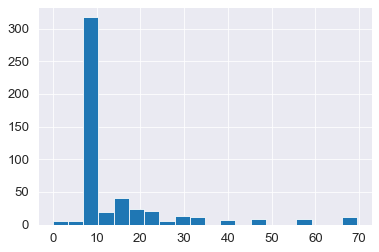

```python
sim_fare['Fare'].hist(bins=20);
```

Will use the mode value here

```python
sim_fare['Fare'].mode()
```

```
0    8.05
dtype: float64
```

```python
full_set['Fare'].fillna(8.05,inplace=True)
```

```python
full_set.drop('Survived',axis=1).isnull().sum()
```

```
Pclass      0
Name        0
Sex         0
Age         0
SibSp       0
Parch       0
Ticket      0
Fare        0
Cabin       0
Embarked    0
dtype: int64
```

### Name feature - exctracting title

```python
full_set['Name'].str.extract(' ([A-Za-z]+)\.', expand=False).value_counts()
```

```
Mr          757
Miss        260
Mrs         197
Master       61
Dr            8
Rev           8
Col           4
Major         2
Ms            2
Mlle          2
Lady          1
Mme           1
Jonkheer      1
Countess      1
Dona          1
Don           1
Sir           1
Capt          1
Name: Name, dtype: int64
```

```python
c = full_set['Name'].tolist()
```

```python
d = []

def ttle(name):
    for i in c:
        if 'Mr.' in i:
            d.append('Mr')
        elif 'Dr.' in i:
            d.append('Mr')
        elif 'Rev.' in i:
            d.append('Mr')
        elif 'Col.' in i:
            d.append('Mr')
        elif 'Capt.' in i:
            d.append('Mr')
        elif 'Major.' in i:
            d.append('Mr')
        elif 'Don.' in i:
            d.append('Mr')
        elif 'Sir.' in i:
            d.append('Mr')

        elif 'Master.' in i:
            d.append('Master')

        elif 'Miss.' in i:
            d.append('Miss')
        elif 'Mlle.' in i:
            d.append('Miss')
        elif 'Mme.' in i:
            d.append('Miss')
        elif 'Ms.' in i:
            d.append('Miss')

        elif 'Mrs.' in i:
            d.append('Mrs')
        elif 'Countess.' in i:
            d.append('Mrs')
        elif 'Lady.' in i:
            d.append('Mrs')
        elif 'Dona.' in i:
            d.append('Mrs')
        else:
            d.append('Mr')

ttle(c)
```

```python
d2 = pd.Series(d)
```

```python
d2.value_counts()
```

```
Mr        783
Miss      265
Mrs       200
Master     61
dtype: int64
```

```python
full_set.reset_index(inplace=True)
```

```python
full_set['title'] = d2
```

```python
full_set.set_index(keys='PassengerId',inplace=True)
```

```python
full_set.tail()
```

| PassengerId | Survived | Pclass | Name | Sex | Age | SibSp | Parch | Ticket | Fare | Cabin | Embarked | title |
| --- | --- | --- | --- | --- | --- | --- | --- | --- | --- | --- | --- | --- |
| 1305 | NaN | 3 | Spector, Mr. Woolf | male | 24.0 | 0 | 0 | A.5. 3236 | 8.0500 | 0 | S | Mr |
| 1306 | NaN | 1 | Oliva y Ocana, Dona. Fermina | female | 39.0 | 0 | 0 | PC 17758 | 108.9000 | 1 | C | Mrs |
| 1307 | NaN | 3 | Saether, Mr. Simon Sivertsen | male | 38.5 | 0 | 0 | SOTON/O.Q. 3101262 | 7.2500 | 0 | S | Mr |
| 1308 | NaN | 3 | Ware, Mr. Frederick | male | 24.0 | 0 | 0 | 359309 | 8.0500 | 0 | S | Mr |
| 1309 | NaN | 3 | Peter, Master. Michael J | male | 24.0 | 1 | 1 | 2668 | 22.3583 | 0 | C | Master |

### Parch and SibSp - The family

```python
def sib_family(row):
    if row['SibSp'] > 0:
        return 1
    else:
        return 0

def par_family(row):
    if row['Parch'] > 0:
        return 1
    else:
        return 0
def family(row):
    if row['Family'] > 0:
        return 1
    else:
        return 0
```

```python
full_set['SibSp'] = full_set.apply(lambda row: sib_family(row),axis=1)
```

```python
full_set['Parch'] = full_set.apply(lambda row: par_family(row),axis=1)
```

```python
full_set['Family'] = full_set['SibSp'] + train['Parch']
```

```python
full_set['Family'] = full_set.apply(lambda row: family(row),axis=1)
full_set['Family'].value_counts()
```

```
0    881
1    428
Name: Family, dtype: int64
```

```python
full_set.head()
```

| PassengerId | Survived | Pclass | Name | Sex | Age | SibSp | Parch | Ticket | Fare | Cabin | Embarked | title | Family |
| --- | --- | --- | --- | --- | --- | --- | --- | --- | --- | --- | --- | --- | --- |
| 1 | 0.0 | 3 | Braund, Mr. Owen Harris | male | 22.0 | 1 | 0 | A/5 21171 | 7.2500 | 0 | S | Mr | 1 |
| 2 | 1.0 | 1 | Cumings, Mrs. John Bradley (Florence Briggs Th... | female | 38.0 | 1 | 0 | PC 17599 | 71.2833 | 1 | C | Mrs | 1 |
| 3 | 1.0 | 3 | Heikkinen, Miss. Laina | female | 26.0 | 0 | 0 | STON/O2. 3101282 | 7.9250 | 0 | S | Miss | 0 |
| 4 | 1.0 | 1 | Futrelle, Mrs. Jacques Heath (Lily May Peel) | female | 35.0 | 1 | 0 | 113803 | 53.1000 | 1 | S | Mrs | 1 |
| 5 | 0.0 | 3 | Allen, Mr. William Henry | male | 35.0 | 0 | 0 | 373450 | 8.0500 | 0 | S | Mr | 0 |

### Tidying up

```python
full_set = full_set.drop(['Fare','Name','SibSp','Parch','Ticket'],axis=1)
```

```python
full_set.head()
```

| PassengerId | Survived | Pclass | Sex | Age | Cabin | Embarked | title | Family |
| --- | --- | --- | --- | --- | --- | --- | --- | --- |
| 1 | 0.0 | 3 | male | 22.0 | 0 | S | Mr | 1 |
| 2 | 1.0 | 1 | female | 38.0 | 1 | C | Mrs | 1 |
| 3 | 1.0 | 3 | female | 26.0 | 0 | S | Miss | 0 |
| 4 | 1.0 | 1 | female | 35.0 | 1 | S | Mrs | 1 |
| 5 | 0.0 | 3 | male | 35.0 | 0 | S | Mr | 0 |

```python
full_set.info()
```

```
<class 'pandas.core.frame.DataFrame'>
Int64Index: 1309 entries, 1 to 1309
Data columns (total 8 columns):
 #   Column    Non-Null Count  Dtype
---  ------    --------------  -----
 0   Survived  891 non-null    float64
 1   Pclass    1309 non-null   int64
 2   Sex       1309 non-null   object
 3   Age       1309 non-null   float64
 4   Cabin     1309 non-null   int64
 5   Embarked  1309 non-null   object
 6   title     1309 non-null   object
 7   Family    1309 non-null   int64
dtypes: float64(2), int64(3), object(3)
memory usage: 124.3+ KB
```

```python
full_set.dtypes
```

```
Survived    float64
Pclass        int64
Sex          object
Age         float64
Cabin         int64
Embarked     object
title        object
Family        int64
dtype: object
```

Breaking up full_data set back to train and test data and exporting to csv to be used for ML algorithms

```python
n = len(train)
```

```python
train_data = full_set[:n]
```

```python
test_data = full_set[n:]
test_data = test_data.drop(['Survived'],axis=1)
```

```python
test_data.shape
```

```
(418, 7)
```

```python
train_data.shape
```

```
(891, 8)
```

```python
train_data.to_csv('train-processed.csv',index=True)
```

```python
test_data.to_csv('test-processed.csv',index=True)
```

# Machine Learning

```python
import pandas as pd
```

```python
train_data = pd.read_csv('train-processed.csv',index_col='PassengerId')
test_data = pd.read_csv('test-processed.csv',index_col='PassengerId')
```

```python
from sklearn.model_selection import train_test_split

X = train_data.drop(['Survived'],axis=1)  # just the features
y = train_data['Survived']                # just the labels
```

```python
X_train, X_test, y_train, y_test = train_test_split(X, y,
                                                    test_size=0.3)
```

```python
X_train
```

| PassengerId | Pclass | Sex | Age | Cabin | Embarked | title | Family |
| --- | --- | --- | --- | --- | --- | --- | --- |
| 426 | 3 | male | 24.0 | 0 | S | Mr | 0 |
| 300 | 1 | female | 50.0 | 1 | C | Mrs | 0 |
| 326 | 1 | female | 36.0 | 1 | C | Miss | 0 |
| 494 | 1 | male | 71.0 | 0 | C | Mr | 0 |
| 526 | 3 | male | 40.5 | 0 | Q | Mr | 0 |
| ... | ... | ... | ... | ... | ... | ... | ... |
| 876 | 3 | female | 15.0 | 0 | C | Miss | 0 |
| 265 | 3 | female | 24.0 | 0 | Q | Miss | 0 |
| 611 | 3 | female | 39.0 | 0 | S | Mrs | 1 |
| 346 | 2 | female | 24.0 | 1 | S | Miss | 0 |
| 809 | 2 | male | 39.0 | 0 | S | Mr | 0 |

623 rows × 7 columns

## Preprocessing

```python
# To display sklearn interactive diagrams:
from sklearn import set_config
set_config(display='diagram')
```

```python
#Load required packages
from sklearn.pipeline import Pipeline
from sklearn.preprocessing import OneHotEncoder, StandardScaler
from sklearn.compose import ColumnTransformer
```

```python
# Creating a list of numerical and categorcal columns based on their dtype
from sklearn.compose import make_column_selector as selector

num_cols = selector(dtype_exclude=object)
cat_cols = selector(dtype_include=object)

num_cols = num_cols(X)
cat_cols = cat_cols(X)
```

```python
#Categorical and numerical columns transformation pipelines
#Encoding categorical columns with scikitlearn OneHotEnccoder
#Scaling the numerical columns with StandardScaler

cat_transformer_onehot = Pipeline(steps=[('onehot_transf',OneHotEncoder(handle_unknown='ignore'))])
num_transformer = Pipeline(steps=[('scaler', StandardScaler())])

#Applying the ColumnTransformer preprocessing for numerical and categorical data
preprocessor = ColumnTransformer([('categoricals', cat_transformer_onehot, cat_cols),
                                  ('numericals', num_transformer, num_cols)],
                                 remainder = 'passthrough')
```

```python
num_transformer
```

```python
cat_transformer_onehot
```

```python
preprocessor
```

## Model Training

### c) Random Forest Classifier

```python
from sklearn.ensemble import RandomForestClassifier
from sklearn.model_selection import RandomizedSearchCV
from sklearn.model_selection import GridSearchCV

rfc_model = RandomForestClassifier()

#Bundle preprocessing and modeling code in a pipeline
my_pipeline_RFC = Pipeline(steps=[('preprocessor', preprocessor),
                                  ('rfc_model', rfc_model)])

#Hyperparameter tuning implementation
param_grid_RFC = {
    'rfc_model__criterion': ['gini','entropy'],
    'rfc_model__n_estimators': [100, 235, 300],
    'rfc_model__max_depth': [10, 30,50, 100],
    'rfc_model__min_samples_split': [5, 15, 25],
    'rfc_model__random_state': [10],

}

searchCV_RFC = RandomizedSearchCV(my_pipeline_RFC,
                                  param_distributions=param_grid_RFC,
                                  cv=5, scoring='accuracy',n_jobs=-1)


#searchCV_RFC = GridSearchCV(my_pipeline_RFC,
#                            param_grid=param_grid_RFC,
#                            cv=5, scoring='accuracy',n_jobs=-1)

final = searchCV_RFC.fit(X_train, y_train)

print('Best parameters for the Random Forest Classifier: \n',
      searchCV_RFC.best_params_)
print('Best accuracy score for the Random Forest Classifier: ',
      searchCV_RFC.best_score_)
```

```
Best parameters for the Random Forest Classifier:
 {'rfc_model__random_state': 10, 'rfc_model__n_estimators': 300, 'rfc_model__min_samples_split': 25, 'rfc_model__max_depth': 30, 'rfc_model__criterion': 'entropy'}
Best accuracy score for the Random Forest Classifier:  0.8170064516129033
```

### Model Evaluation

```python
best_model_RFC = RandomForestClassifier(criterion = 'entropy',
                                        max_depth=30,
                                        min_samples_split= 25,
                                        n_estimators= 300,
                                        random_state= 10,
                                        )


my_pipeline_best_RFC = Pipeline(steps=[('preprocessor', preprocessor),
                                       ('best_model_RFC', best_model_RFC)])
```

```python
from sklearn.model_selection import cross_validate
from sklearn.model_selection import ShuffleSplit

cv = ShuffleSplit(n_splits=100, test_size=0.3, random_state=0)

cv_results = cross_validate(my_pipeline_best_RFC,
                            X_test,
                            y_test,
                            cv=cv,
                            scoring="accuracy",
                            return_train_score=True)
```

```python
cv_results = pd.DataFrame(cv_results)#[['test_score','train_score']])
cv_results.head()
```

|  | fit_time | score_time | test_score | train_score |
| --- | --- | --- | --- | --- |
| 0 | 0.399297 | 0.035346 | 0.814815 | 0.828877 |
| 1 | 0.354574 | 0.033772 | 0.777778 | 0.834225 |
| 2 | 0.361447 | 0.034167 | 0.814815 | 0.828877 |
| 3 | 0.364495 | 0.033820 | 0.765432 | 0.855615 |
| 4 | 0.411376 | 0.034151 | 0.777778 | 0.850267 |

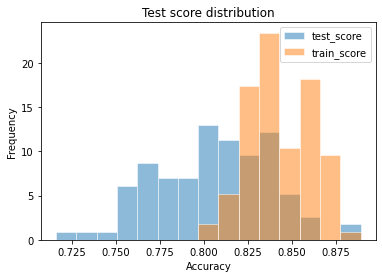

```python
import matplotlib.pyplot as plt

cv_results[['test_score','train_score']].plot.hist(bins=15, edgecolor="white", density=True,alpha=0.5)
plt.xlabel("Accuracy")
_ = plt.title("Test score distribution")
```

```python
print(f"Classifier accuracy is on the test dataset was: {cv_results['test_score'].min():.2f} +/- {cv_results['test_score'].std():.2f}")
```

[output not shown]

### Kaggle Submission

```python
my_pipeline_final = searchCV_RFC.best_estimator_
predictions = my_pipeline_final.predict(test_data)
```

```python
final_data = predictions.astype(int)
```

```python
#Generate output
output = pd.DataFrame({'PassengerId': test_data.index,
                       'Survived': final_data})
output.to_csv('submission_v12-rfc.csv', index=False)
print("File saved!")
```

```
File saved!
```